# Group_1_Project

The only numeric data that this file contains is `vei`, `latitude`, `longitude`, and the various columns for start and end day, month, and year. Out of these existing values, it only makes sense to calculate the mean of the VEI, which we showed in addition to the previous histogram. However, we can create an additional column from this data for the length of each eruption in days. We first must put the day, month, and year in the same column for the start and end dates, then convert these values to dates using the `as.Date()` function from base R. Then, we can use `mutate()` to take the end date minus the start date to get length of eruption in days. Following this step, we can create jitter plots that show the different day at specified levels of VEI. Because there are several outliers that compress the data, we created a second jitter plot that shows only data within one standard deviation of the mean lenght of eruption. We can see that eruption lengths vary widely within individual VEI categories.

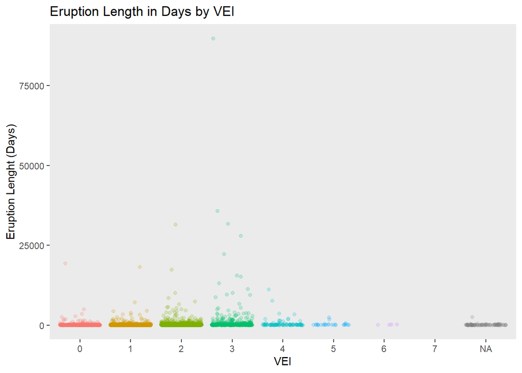

```r
eruptions_updated<-eruptions%>%
  transform(start_date=interaction(start_year, start_month, start_day, sep="-"))%>%
  transform(end_date=interaction(end_year, end_month, end_day, sep="-"))
eruptions_updated$start_date<-as.Date(eruptions_updated$start_date)
eruptions_updated$end_date<-as.Date(eruptions_updated$end_date)
eruptions_updated$vei<-as.factor(eruptions_updated$vei)
eruptions_updated<-eruptions_updated%>%
  mutate(eruption_length_in_days=end_date - start_date)
eruptions_updated$eruption_length_in_days<-as.numeric(eruptions_updated$eruption_length_in_days)
write.table(eruptions_updated, file.path(data_sets_path,"updated_eruptions_data_set.txt"))

#All Data Points
ggplot(eruptions_updated, aes(x=vei, y=eruption_length_in_days))+
  geom_jitter(aes(color=vei), alpha=1/5, show.legend=F)+
  ggtitle("Eruption Length in Days by VEI")+
  labs(x="VEI", y="Eruption Lenght (Days)")+
  theme(panel.grid = element_blank())+
  ggsave(file.path(figure_path, "eruption_length_by_vei.pdf"))
```

```r
mean(eruptions_updated$eruption_length_in_days, na.rm=T)+sd(eruptions_updated$eruption_length_in_days, na.rm=T)
```

```
## [1] 2465.113
```

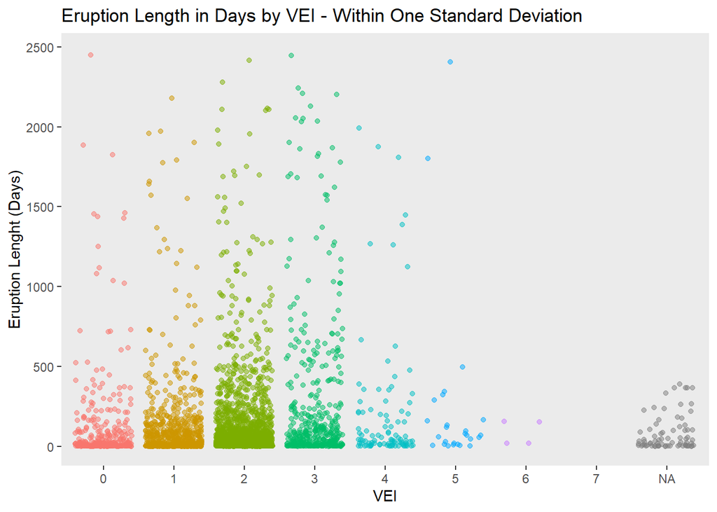

```r
#Data Points within One SD of Mean
ggplot(eruptions_updated, aes(x=vei, y=eruption_length_in_days))+
  geom_jitter(aes(color=vei), alpha=1/2, show.legend = F)+
  ylim(0,2465)+
  ggtitle("Eruption Length in Days by VEI - Within One Standard Deviation")+
  labs(x="VEI", y="Eruption Lenght (Days)")+
  theme(panel.grid = element_blank())+
  ggsave(file.path(figure_path, "eruption_length_by_vei_in_one_SD.pdf"))
```

*Methods of Dating Past Volcanic Eruptions*

Here we create several bar plots displaying the different methods used for dating various eruptions of volcanos. The first plot is of the raw data. A high number of individuals categorized as “Historical Observations” compresses the rest of the bars in the plot, so we remove all individuals with “Historical Observations” to create the new data set `eruptions2`. Then, we create a new bar plot that includes all methods used besides “Historical Observations”. As can be seen, visualization of the different amounts is made much easier by removing this factor.

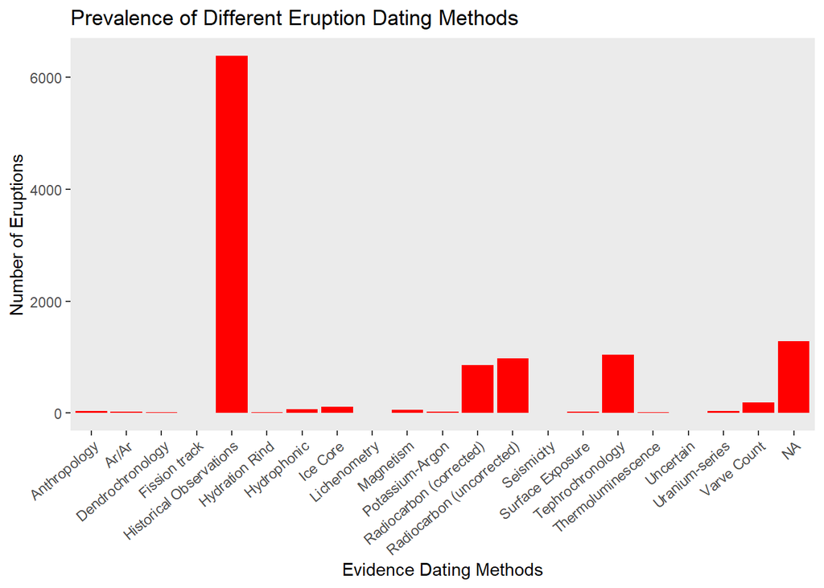

```r
ggplot(eruptions, aes(x=evidence_method_dating))+
  geom_bar(fill="red")+
  ggtitle("Prevalence of Different Eruption Dating Methods")+
  labs(x="Evidence Dating Methods", y="Number of Eruptions")+
  theme(panel.grid=element_blank(), axis.text.x = element_text(angle = 40, hjust = 1, vjust = 1))+
  ggsave(file.path(figure_path, "eruptions_by_evidence_method.pdf"))
```

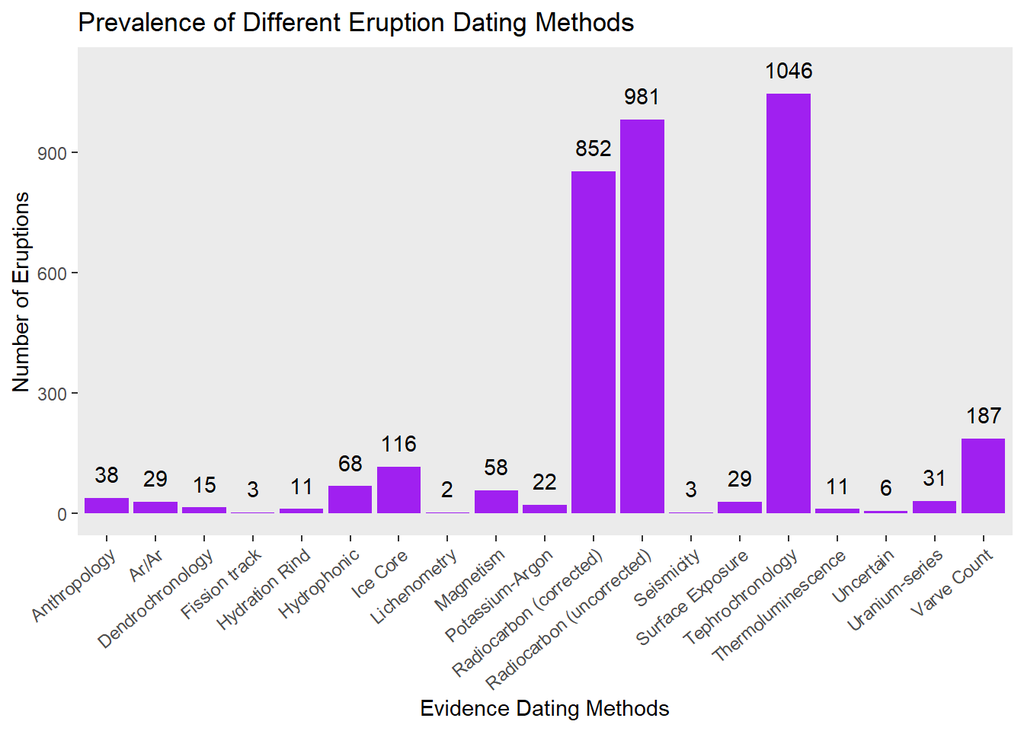

```r
eruptions2 <- filter(eruptions, evidence_method_dating != "Historical Observations")

evidence_count2<-eruptions2 %>%
  group_by(evidence_method_dating) %>%
  summarise(no_rows5 = length(evidence_method_dating))
ggplot(eruptions2, aes(x=evidence_method_dating))+
  geom_bar(fill="purple")+
  ggtitle("Prevalence of Different Eruption Dating Methods")+
  labs(x="Evidence Dating Methods", y="Number of Eruptions")+
  theme(panel.grid=element_blank(), axis.text.x = element_text(angle = 40, hjust = 1, vjust = 1))+
  geom_text(data=evidence_count2, aes(x=evidence_method_dating, y=no_rows5, label=no_rows5), nudge_y=60)+
  ggsave(file.path(figure_path, "eruptions_by_evidence_method_without_hist_obs.pdf"))
```